# Akula-DATA605-Week03-HW3

Pavan Akula

September 16, 2017

```r
library(pracma)
```

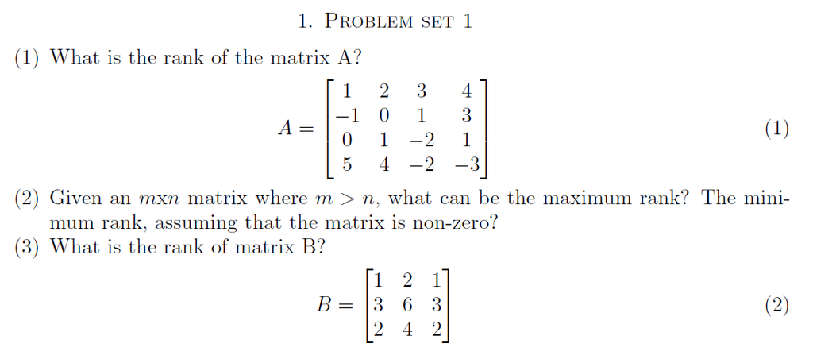

*A: (1)*

*The set of pivot columns of any reduced row echelon form matrix is known as Rank.*

```r
#Create a matrix
A = matrix(c(1,-1,0,5, 2,0,1,4, 3,1,-2,-2, 4,3,1,-3),ncol = 4)

A
```

```
##      [,1] [,2] [,3] [,4]
## [1,]    1    2    3    4
## [2,]   -1    0    1    3
## [3,]    0    1   -2    1
## [4,]    5    4   -2   -3
```

```r
#Using qr function calculate rank
rankA <- qr(A)
rankA$rank
```

```
## [1] 4
```

*Rank of the matrix A: 4*

```r
#reduced row echelon form matrix
rrefA = rref(A)
rrefA
```

```
##      [,1] [,2] [,3] [,4]
## [1,]    1    0    0    0
## [2,]    0    1    0    0
## [3,]    0    0    1    0
## [4,]    0    0    0    1
```

*Reduced row echelon form of matrix A shows each column is linearly indepentent, hence rank is 4.*

*A: (2)*

*According to theorem Computing Rank and Nullity(CRN), suppose that A is an m x n matrix and B is a row-equivalent matrix in reduced row-echelon form. Let r denote the number of pivot columns (or the number of nonzero rows). Then $r(A) = r$ and $n(A) = n - r$.*

*According to theorem Rank Plus Nullity(RPNC) is Columns, suppose that A is an m x n matrix. Then $r(A) + n(A) = n$.*

*Using given conditions of the problem, m > n, hence $r(A) \le n$.*

*A: (3)*

```r
#Create a matrix
B = matrix(c(1,3,2, 2,6,4, 1,3,2),ncol = 3)

B
```

```
##      [,1] [,2] [,3]
## [1,]    1    2    1
## [2,]    3    6    3
## [3,]    2    4    2
```

```r
#Using qr function calculate rank
rankB <- qr(B)
rankB$rank
```

```
## [1] 1
```

*Rank of the matrix B: 1*

```r
#reduced row echelon form matrix
rrefB = rref(B)
rrefB
```

```
##      [,1] [,2] [,3]
## [1,]    1    2    1
## [2,]    0    0    0
## [3,]    0    0    0
```

*Reduced row echelon form of matrix B shows only one non-zero row, hence rank is 1.*

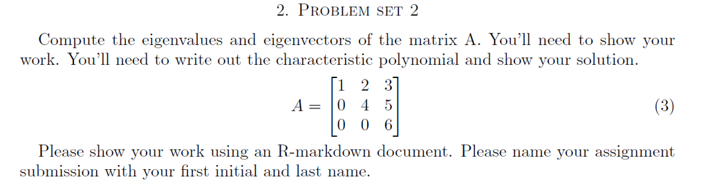

*A: Characteristic polynomial*

```r
#define matrix
A = matrix(c(1,0,0, 2,4,0, 3,5,6),ncol = 3)

cp = charpoly(A)

#Characteristic polynomial
cp
```

```
## [1]   1 -11  34 -24
```

*Characteristic polynomial equation for given matrix is $1x^3 -11x^2 + 34x -24$*

*Eigenvalues*

*According to theorem EMRCP, Eigenvalues of a Matrix are Roots of Characteristic Polynomials Suppose A is a square matrix. Then $\lambda$ is an eigenvalue of A if and only if $p_{A} (\lambda) = 0$*

*By setting the characteristic polynomial equation equal to zero, $p_{A}(x) = 1x^3 -11x^2 + 34x -24 = 0$*

```r
ev = eigen(A)
ev$values
```

```
## [1] 6 4 1
```

*Roots are $x = 6, x = 4$ and $x = 1$.*

*Eigenvalues of given matrix are $\lambda = 6, \lambda = 4$ and $\lambda = 1$*

*Eigenvectors*

*$\lambda = 6, A - \lambda I_{3}$*

```r
lambda = ev$values[1]
lambdaI = lambda * diag(3)

result = A - lambdaI

#using pracma library get reduced row echelon form for result
rrefMx = rref(result)
rrefMx
```

```
##      [,1] [,2] [,3]
## [1,]    1    0 -1.6
## [2,]    0    1 -2.5
## [3,]    0    0  0.0
```

*Null space, ${\cal E}_{A}(6) = {\cal N}(A - (6I_{3}))$*

${\cal N}(A + 6I_{3}) = \left[\begin{array}{cc}1 & 0 & -1.6 \\0 & 1 & -2.5 \\0 & 0 & 0 \end{array}\right] \left[\begin{array}{cc}v_1 \\ v_2 \\ v_3\end{array}\right] = \left[\begin{array}{cc}0 \\ 0 \\ 0\end{array}\right]$

*Solving the equations,* $v_1 -1.6v_3 = 0,\ v_2 -2.5v_3 = 0$

$if\ v_3 = t, then\ v_1 = 1.6t, v_2 = 2.5t$

${\cal E}_{A}(6) = \left\{\left[\begin{array}{cc} v_1 \\ v_2 \\ v_3\end{array}\right] = t\left[\begin{array}{cc} 1.6 \\ 2.5 \\ 1\end{array}\right] | t\ \epsilon\ Real\ Numbers\right\}$

*Eigenspace for $\lambda = 6$ is ${\cal E}_{A}(6) = \left\langle\left[\begin{array}{cc} 1.6 \\ 2.5 \\ 1\end{array}\right]\right\rangle$*

*$\lambda = 4, A - \lambda I_{3}$*

```r
lambda = ev$values[2]
lambdaI = lambda * diag(3)

result = A - lambdaI

#using pracma library get reduced row echelon form for result
rrefMx = rref(result)
rrefMx
```

```
##      [,1]       [,2] [,3]
## [1,]    1 -0.6666667    0
## [2,]    0  0.0000000    1
## [3,]    0  0.0000000    0
```

*Null space, ${\cal E}_{A}(4) = {\cal N}(A - (4I_{3}))$*

${\cal N}(A + 4I_{3}) = \left[\begin{array}{cc}1 & -0.6666667 & 0 \\0 & 0 & 1 \\0 & 0 & 0 \end{array}\right] \left[\begin{array}{cc}v_1 \\ v_2 \\ v_3\end{array}\right] = \left[\begin{array}{cc}0 \\ 0 \\ 0\end{array}\right]$

*Solving the equations,* $v_1 -0.6666667v_2 = 0,\ v_3 = 0$

$if\ v_2 = t, then\ v_1 = 0.6666667t$

${\cal E}_{A}(4) = \left\{\left[\begin{array}{cc} v_1 \\ v_2 \\ v_3\end{array}\right] = t\left[\begin{array}{cc} 0.6666667 \\ 1 \\ 0\end{array}\right] | t\ \epsilon\ Real\ Numbers\right\}$

*Let $t = 0.6666667 | {t\ \epsilon\ Real\ Numbers}$*

${\cal E}_{A}(4) = \left\{\left[\begin{array}{cc} v_1 \\ v_2 \\ v_3\end{array}\right] = 0.6666667\left[\begin{array}{cc} 1 \\ 1.5 \\ 0\end{array}\right] | t\ \epsilon\ Real\ Numbers\right\}$

*Eigenspace for $\lambda = 4$ is ${\cal E}_{A}(4) = \left\langle\left[\begin{array}{cc} 1 \\ 1.5 \\ 0\end{array}\right]\right\rangle$*

*$\lambda = 1, A - \lambda I_{3}$*

```r
lambda = ev$values[3]
lambdaI = lambda * diag(3)

result = A - lambdaI

#using pracma library get reduced row echelon form for result
rrefMx = rref(result)
rrefMx
```

```
##      [,1] [,2] [,3]
## [1,]    0    1    0
## [2,]    0    0    1
## [3,]    0    0    0
```

*Null space, ${\cal E}_{A}(1) = {\cal N}(A - (1I_{3}))$*

${\cal N}(A + 1I_{3}) = \left[\begin{array}{cc}0 & 1 & 0 \\0 & 0 & 1 \\0 & 0 & 0 \end{array}\right] \left[\begin{array}{cc}v_1 \\ v_2 \\ v_3\end{array}\right] = \left[\begin{array}{cc}0 \\ 0 \\ 0\end{array}\right]$

*Solving the equations,* $v_2 = 0,\ v_3 = 0$

$let\ v_1 = t$

${\cal E}_{A}(1) = \left\{\left[\begin{array}{cc} v_1 \\ v_2 \\ v_3\end{array}\right] = t\left[\begin{array}{cc} 1 \\ 0 \\ 0\end{array}\right] | t\ \epsilon\ Real\ Numbers\right\}$

*Eigenspace for $\lambda = 1$ is ${\cal E}_{A}(1) = \left\langle\left[\begin{array}{cc} 1 \\ 0 \\ 0\end{array}\right]\right\rangle$*

*Solving using eigen function from R*

```r
#eigenvectors values from eigen function
ev$vectors
```

```
##           [,1]      [,2] [,3]
## [1,] 0.5108407 0.5547002    1
## [2,] 0.7981886 0.8320503    0
## [3,] 0.3192754 0.0000000    0
```

*Eigenspace for $\lambda = 6$*

```r
#for lambda to 6
ev$values[1]
```

```
## [1] 6
```

```r
es = ev$vectors[,1]
es
```

```
## [1] 0.5108407 0.7981886 0.3192754
```

```r
#let minT be min value of vector
minT = min(es)
```

${\cal E}_{A}(6) = \left\{\left[\begin{array}{cc} v_1 \\ v_2 \\ v_3\end{array}\right] = t\left[\begin{array}{cc} 0.5108407 \\ 0.7981886 \\ 0.3192754\end{array}\right] | t\ \epsilon\ Real\ Numbers\right\}$

*Let $t = 0.3192754 | {t\ \epsilon\ Real\ Numbers}$*

${\cal E}_{A}(6) = \left\{\left[\begin{array}{cc} v_1 \\ v_2 \\ v_3\end{array}\right] = 0.3192754\left[\begin{array}{cc} 1.6 \\ 2.5 \\ 1\end{array}\right] | 0.3192754\ \epsilon\ Real\ Numbers\right\}$

*Eigenspace for $\lambda = 6$ is ${\cal E}_{A}(6) = \left\langle\left[\begin{array}{cc} 1.6 \\ 2.5 \\ 1\end{array}\right]\right\rangle$*

*Eigenspace for $\lambda = 4$*

```r
#for lambda to 4
ev$values[2]
```

```
## [1] 4
```

```r
es = ev$vectors[,2]
es
```

```
## [1] 0.5547002 0.8320503 0.0000000
```

```r
#let minT be min value of vector
minT = min(es[es > 0])
```

${\cal E}_{A}(4) = \left\{\left[\begin{array}{cc} v_1 \\ v_2 \\ v_3\end{array}\right] = t\left[\begin{array}{cc} 0.5547002 \\ 0.8320503 \\ 0\end{array}\right] | t\ \epsilon\ Real\ Numbers\right\}$

*Let $t = 0.5547002 | {t\ \epsilon\ Real\ Numbers}$*

${\cal E}_{A}(4) = \left\{\left[\begin{array}{cc} v_1 \\ v_2 \\ v_3\end{array}\right] = 0.5547002\left[\begin{array}{cc} 1 \\ 1.5 \\ 0\end{array}\right] | 0.5547002\ \epsilon\ Real\ Numbers\right\}$

*Eigenspace for $\lambda = 4$ is ${\cal E}_{A}(4) = \left\langle\left[\begin{array}{cc} 1 \\ 1.5 \\ 0\end{array}\right]\right\rangle$*

*Eigenspace for $\lambda = 1$*

```r
#for lambda to 1
ev$values[3]
```

```
## [1] 1
```

```r
es = ev$vectors[,3]
es
```

```
## [1] 1 0 0
```

```r
#let minT be min value of vector
minT = min(es[es > 0])
```

${\cal E}_{A}(1) = \left\{\left[\begin{array}{cc} v_1 \\ v_2 \\ v_3\end{array}\right] = t\left[\begin{array}{cc} 1 \\ 0 \\ 0\end{array}\right] | t\ \epsilon\ Real\ Numbers\right\}$

*Let $t = 1 | {t\ \epsilon\ Real\ Numbers}$*

${\cal E}_{A}(1) = \left\{\left[\begin{array}{cc} v_1 \\ v_2 \\ v_3\end{array}\right] = 1\left[\begin{array}{cc} 1 \\ 0 \\ 0\end{array}\right] | 1\ \epsilon\ Real\ Numbers\right\}$

*Eigenspace for $\lambda = 1$ is ${\cal E}_{A}(1) = \left\langle\left[\begin{array}{cc} 1 \\ 0 \\ 0\end{array}\right]\right\rangle$*

*Eigenspace values are same, solving manually matches R function eigen.*